# Project 1: Wrangling, Exploration, Visualization

SDS322E

## Data Wrangling, Exploration, Visualization

### Rebecca Gu rjg2836

#### Introduction

The datasets I have chosen are college_grad_students and college_all_ages from fivethirtyeight. The data was obtained from American Community Survey 2010-2012 Public Use Microdata Series. college_grad_students, or grad, is a data frame with 173 rows representing majors (graduate vs nongraduate students) and 22 variables. college_all_ages, or all, is a data frame with 173 rows representing majors (all ages) and 11 variables. The variables describe the employment rates, total counts, incomes, major category, and major. “grad” differs from “all” by splitting the first three variables listed before into those who graduated and those who did not. Thus, it contains more specific information than “all”. This dataset is interesting to me because choosing college majors seems like a daunting task that controls the rest of your life, and many people pick randomly. I would like to see the quantitative data that shows what majors are the most lucrative. Also, as an Economics major, I feel looked down on since it’s Liberal Arts, and it would interest me to see just how much more engineering majors make. I expect engineering to make the most, and for those with degrees to earn significantly more than those who did not.

```r
# read your datasets in here, e.g., with read_csv()
library(tidyverse)
library(knitr)
options(scipen = 10000)
library(fivethirtyeight)

grad <- college_grad_students
all <- college_all_ages
```

#### Tidying: Reshaping

```r
# Tidyed joined data
```

#### Joining/Merging

```r
joined <- left_join(all, grad, by = "major_code", suffix = c("",
    ".y"))
# total observations/rows in each dataset
dim(all)
```

```
## [1] 173  11
```

```r
dim(grad)
```

```
## [1] 173  22
```

```r
dim(joined)
```

```
## [1] 173  32
```

```r
# unique IDs in each dataset
all %>% count(n_distinct(major_code))
```

```
## # A tibble: 1 x 2
##   `n_distinct(major_code)`     n
##                      <int> <int>
## 1                      173   173
```

```r
grad %>% count(n_distinct(major_code))
```

```
## # A tibble: 1 x 2
##   `n_distinct(major_code)`     n
##                      <int> <int>
## 1                      173   173
```

```r
joined %>% count(n_distinct(major_code))
```

```
## # A tibble: 1 x 2
##   `n_distinct(major_code)`     n
##                      <int> <int>
## 1                      173   173
```

```r
# IDs that appear in one dataset but not the other (and which
# those are)
anti_join(all, grad, by = "major_code")
```

```
## # A tibble: 0 x 11
## # … with 11 variables: major_code <int>, major <chr>, major_category <chr>,
## #   total <int>, employed <int>, employed_fulltime_yearround <int>,
## #   unemployed <int>, unemployment_rate <dbl>, p25th <dbl>, median <dbl>,
## #   p75th <dbl>
```

```r
# IDs the datasets have common
inner_join(all, grad, by = "major_code")
```

```
## # A tibble: 173 x 32
##    major_code major.x major_category.x  total employed employed_fullti…
##         <int> <chr>   <chr>             <int>    <int>            <int>
##  1       1100 Genera… Agriculture & N… 128148    90245            74078
##  2       1101 Agricu… Agriculture & N…  95326    76865            64240
##  3       1102 Agricu… Agriculture & N…  33955    26321            22810
##  4       1103 Animal… Agriculture & N… 103549    81177            64937
##  5       1104 Food S… Agriculture & N…  24280    17281            12722
##  6       1105 Plant … Agriculture & N…  79409    63043            51077
##  7       1106 Soil S… Agriculture & N…   6586     4926             4042
##  8       1199 Miscel… Agriculture & N…   8549     6392             5074
##  9       1301 Enviro… Biology & Life … 106106    87602            65238
## 10       1302 Forest… Agriculture & N…  69447    48228            39613
## # … with 163 more rows, and 26 more variables: unemployed <int>,
## #   unemployment_rate <dbl>, p25th <dbl>, median <dbl>, p75th <dbl>,
## #   major.y <chr>, major_category.y <chr>, grad_total <int>,
## #   grad_sample_size <int>, grad_employed <int>,
## #   grad_employed_fulltime_yearround <int>, grad_unemployed <int>,
## #   grad_unemployment_rate <dbl>, grad_p25th <dbl>, grad_median <dbl>,
## #   grad_p75th <int>, nongrad_total <int>, nongrad_employed <int>,
## #   nongrad_employed_fulltime_yearround <int>, nongrad_unemployed <int>,
## #   nongrad_unemployment_rate <dbl>, nongrad_p25th <dbl>, nongrad_median <dbl>,
## #   nongrad_p75th <dbl>, grad_share <dbl>, grad_premium <dbl>
```

```r
joined %>% pivot_wider(names_from = "major_category", values_from = "total") %>%
    pivot_longer(29:44, names_to = "major_category", values_to = "total",
        values_drop_na = T)
```

```
## # A tibble: 498 x 32
##    major_code major employed employed_fullti… unemployed unemployment_ra… p25th
##         <int> <chr>    <int>            <int>      <int>            <dbl> <dbl>
##  1       1100 Gene…    90245            74078       2423           0.0261 34000
##  2       1100 Gene…    90245            74078       2423           0.0261 34000
##  3       1100 Gene…    90245            74078       2423           0.0261 34000
##  4       1101 Agri…    76865            64240       2266           0.0286 36000
##  5       1101 Agri…    76865            64240       2266           0.0286 36000
##  6       1101 Agri…    76865            64240       2266           0.0286 36000
##  7       1102 Agri…    26321            22810        821           0.0302 40000
##  8       1102 Agri…    26321            22810        821           0.0302 40000
##  9       1102 Agri…    26321            22810        821           0.0302 40000
## 10       1103 Anim…    81177            64937       3619           0.0427 30000
## # … with 488 more rows, and 25 more variables: median <dbl>, p75th <dbl>,
## #   major.y <chr>, major_category.y <chr>, grad_total <int>,
## #   grad_sample_size <int>, grad_employed <int>,
## #   grad_employed_fulltime_yearround <int>, grad_unemployed <int>,
## #   grad_unemployment_rate <dbl>, grad_p25th <dbl>, grad_median <dbl>,
## #   grad_p75th <int>, nongrad_total <int>, nongrad_employed <int>,
## #   nongrad_employed_fulltime_yearround <int>, nongrad_unemployed <int>,
## #   nongrad_unemployment_rate <dbl>, nongrad_p25th <dbl>, nongrad_median <dbl>,
## #   nongrad_p75th <dbl>, Arts <int>, Business <int>, major_category <chr>,
## #   total <dbl>
```

In the original “all” dataset, there were 173 observations and 11 variables, each observation being an unique major. In the “grad” dataset there were 173 observations and 22 variables, each observation being an unique major. I chose left join because I wanted all the information from both datsets, and this allowed me to do that. I could have done inner join but I am not as comfortable with that. I left joined the “grad” dataset to the “all” dataset. They had a common ID of major code, which is a four digit unique identifier for each major. I could have also joined by the major name. Once joined, there were 173 observations and 32 variables, each observation being an unique major. This makes the size of the joined dataset the size of (the two original datasets - 1) because the joined ID variable only counts once. 2/32 variables will be dropped in wrangling. There were no IDs that appeared in one but not the other, and no observations were dropped. I included the suffix parameter because both datasets have “major” and “major_category” as variables. Since I only need one set of them, I uniquely identified the second set with “.y” so that I can easily drop it later with contains().

#### Wrangling

```r
joined <- joined %>% select(!contains(".y"))
joined %>% arrange(desc(median)) %>% group_by(major_category) %>%
    slice(1:4)
```

```
## # A tibble: 61 x 30
## # Groups:   major_category [16]
##    major_code major major_category  total employed employed_fullti… unemployed
##         <int> <chr> <chr>           <int>    <int>            <int>      <int>
##  1       1102 Agri… Agriculture &…  33955    26321            22810        821
##  2       1106 Soil… Agriculture &…   6586     4926             4042        264
##  3       1104 Food… Agriculture &…  24280    17281            12722        894
##  4       1302 Fore… Agriculture &…  69447    48228            39613       2144
##  5       6005 Film… Arts           133508   107651            69303      10080
##  6       6004 Comm… Arts           504657   379980           266671      30330
##  7       6000 Fine… Arts           571961   386961           256747      29912
##  8       6002 Music Arts           276262   192704           116142      11155
##  9       3606 Micr… Biology & Lif…  68885    45422            33990       2435
## 10       3607 Phar… Biology & Lif…   5015     3481             2579         57
## # … with 51 more rows, and 23 more variables: unemployment_rate <dbl>,
## #   p25th <dbl>, median <dbl>, p75th <dbl>, grad_total <int>,
## #   grad_sample_size <int>, grad_employed <int>,
## #   grad_employed_fulltime_yearround <int>, grad_unemployed <int>,
## #   grad_unemployment_rate <dbl>, grad_p25th <dbl>, grad_median <dbl>,
## #   grad_p75th <int>, nongrad_total <int>, nongrad_employed <int>,
## #   nongrad_employed_fulltime_yearround <int>, nongrad_unemployed <int>,
## #   nongrad_unemployment_rate <dbl>, nongrad_p25th <dbl>, nongrad_median <dbl>,
## #   nongrad_p75th <dbl>, grad_share <dbl>, grad_premium <dbl>
```

```r
joined %>% mutate(diffp75 = grad_p75th - p75th, diffmed = grad_median -
    median, diffp25 = grad_p25th - p25th) %>% arrange(desc(diffmed))
```

```
## # A tibble: 173 x 33
##    major_code major major_category  total employed employed_fullti… unemployed
##         <int> <chr> <chr>           <int>    <int>            <int>      <int>
##  1       6106 Heal… Health          32514    19009            13147       1431
##  2       3609 Zool… Biology & Lif…  55395    35714            26152       1815
##  3       3607 Phar… Biology & Lif…   5015     3481             2579         57
##  4       3600 Biol… Biology & Lif… 839454   583079           422788      36757
##  5       3601 Bioc… Biology & Lif…  75322    52594            37103       4056
##  6       4006 Cogn… Biology & Lif…   6898     5527             3639        284
##  7       5003 Chem… Physical Scie… 308062   198075           153308      11468
##  8       3603 Mole… Biology & Lif…  28197    20221            13366       1303
##  9       3608 Phys… Biology & Lif…  43984    31394            20207       1692
## 10       6202 Actu… Business         9763     7846             6880        466
## # … with 163 more rows, and 26 more variables: unemployment_rate <dbl>,
## #   p25th <dbl>, median <dbl>, p75th <dbl>, grad_total <int>,
## #   grad_sample_size <int>, grad_employed <int>,
## #   grad_employed_fulltime_yearround <int>, grad_unemployed <int>,
## #   grad_unemployment_rate <dbl>, grad_p25th <dbl>, grad_median <dbl>,
## #   grad_p75th <int>, nongrad_total <int>, nongrad_employed <int>,
## #   nongrad_employed_fulltime_yearround <int>, nongrad_unemployed <int>,
## #   nongrad_unemployment_rate <dbl>, nongrad_p25th <dbl>, nongrad_median <dbl>,
## #   nongrad_p75th <dbl>, grad_share <dbl>, grad_premium <dbl>, diffp75 <dbl>,
## #   diffmed <dbl>, diffp25 <dbl>
```

```r
joined %>% filter(total > mean(total)) %>% summarize(mean(median))
```

```
## # A tibble: 1 x 1
##   `mean(median)`
##            <dbl>
## 1         55702.
```

```r
joined %>% filter(str_detect(major, "Economics"))
```

```
## # A tibble: 3 x 30
##   major_code major major_category  total employed employed_fullti… unemployed
##        <int> <chr> <chr>           <int>    <int>            <int>      <int>
## 1       1102 Agri… Agriculture &…  33955    26321            22810        821
## 2       5501 Econ… Social Science 757616   535446           430580      34974
## 3       6205 Busi… Business        75547    57983            48471       3816
## # … with 23 more variables: unemployment_rate <dbl>, p25th <dbl>, median <dbl>,
## #   p75th <dbl>, grad_total <int>, grad_sample_size <int>, grad_employed <int>,
## #   grad_employed_fulltime_yearround <int>, grad_unemployed <int>,
## #   grad_unemployment_rate <dbl>, grad_p25th <dbl>, grad_median <dbl>,
## #   grad_p75th <int>, nongrad_total <int>, nongrad_employed <int>,
## #   nongrad_employed_fulltime_yearround <int>, nongrad_unemployed <int>,
## #   nongrad_unemployment_rate <dbl>, nongrad_p25th <dbl>, nongrad_median <dbl>,
## #   nongrad_p75th <dbl>, grad_share <dbl>, grad_premium <dbl>
```

```r
# summary statistics
joined %>% group_by(major_category) %>% summarize(Count = n())
```

```
## # A tibble: 16 x 2
##    major_category                      Count
##    <chr>                               <int>
##  1 Agriculture & Natural Resources        10
##  2 Arts                                    8
##  3 Biology & Life Science                 14
##  4 Business                               13
##  5 Communications & Journalism             4
##  6 Computers & Mathematics                11
##  7 Education                              16
##  8 Engineering                            29
##  9 Health                                 12
## 10 Humanities & Liberal Arts              15
## 11 Industrial Arts & Consumer Services     7
## 12 Interdisciplinary                       1
## 13 Law & Public Policy                     5
## 14 Physical Sciences                      10
## 15 Psychology & Social Work                9
## 16 Social Science                          9
```

```r
joined %>% group_by(major_category) %>% summarize(Mean = mean(unemployment_rate),
    StDev = sd(unemployment_rate), Count = n()) %>% kable(digits = 3,
    align = "c", col.names = c("Major Category", "Mean", "StDev",
        "Count"), caption = "Unemployment Rates")
```

Unemployment Rates

| Major Category | Mean | StDev | Count |
| --- | --- | --- | --- |
| Agriculture & Natural Resources | 0.040 | 0.010 | 10 |
| Arts | 0.088 | 0.030 | 8 |
| Biology & Life Science | 0.050 | 0.014 | 14 |
| Business | 0.054 | 0.008 | 13 |
| Communications & Journalism | 0.069 | 0.010 | 4 |
| Computers & Mathematics | 0.059 | 0.018 | 11 |
| Education | 0.047 | 0.023 | 16 |
| Engineering | 0.051 | 0.016 | 29 |
| Health | 0.047 | 0.016 | 12 |
| Humanities & Liberal Arts | 0.069 | 0.010 | 15 |
| Industrial Arts & Consumer Services | 0.059 | 0.019 | 7 |
| Interdisciplinary | 0.077 | NA | 1 |
| Law & Public Policy | 0.068 | 0.009 | 5 |
| Physical Sciences | 0.055 | 0.015 | 10 |
| Psychology & Social Work | 0.078 | 0.013 | 9 |
| Social Science | 0.066 | 0.005 | 9 |

```r
joined %>% summarize_all(function(x) sum(is.na(x)))
```

```
## # A tibble: 1 x 30
##   major_code major major_category total employed employed_fullti… unemployed
##        <int> <int>          <int> <int>    <int>            <int>      <int>
## 1          0     0              0     0        0                0          0
## # … with 23 more variables: unemployment_rate <int>, p25th <int>, median <int>,
## #   p75th <int>, grad_total <int>, grad_sample_size <int>, grad_employed <int>,
## #   grad_employed_fulltime_yearround <int>, grad_unemployed <int>,
## #   grad_unemployment_rate <int>, grad_p25th <int>, grad_median <int>,
## #   grad_p75th <int>, nongrad_total <int>, nongrad_employed <int>,
## #   nongrad_employed_fulltime_yearround <int>, nongrad_unemployed <int>,
## #   nongrad_unemployment_rate <int>, nongrad_p25th <int>, nongrad_median <int>,
## #   nongrad_p75th <int>, grad_share <int>, grad_premium <int>
```

```r
joined %>% group_by(major_category) %>% summarize(AvgDiffQ1 = mean(grad_p25th -
    p25th), AvgDiffMedian = mean(grad_median - median), AvgDiffQ3 = mean(grad_p75th -
    p75th))
```

```
## # A tibble: 16 x 4
##    major_category                      AvgDiffQ1 AvgDiffMedian AvgDiffQ3
##    <chr>                                   <dbl>         <dbl>     <dbl>
##  1 Agriculture & Natural Resources        65450         14130    -33340
##  2 Arts                                   51762.        13019.   -24125
##  3 Biology & Life Science                103857.        32179.   -26614.
##  4 Business                               81454.        23538.   -35269.
##  5 Communications & Journalism            60000         13500    -32500
##  6 Computers & Mathematics                72773.        19273.   -37218.
##  7 Education                              43778.        14606.   -13032.
##  8 Engineering                            78776.        16569.   -42562.
##  9 Health                                 80017.        23833.   -21800
## 10 Humanities & Liberal Arts              71120         21253.   -25293.
## 11 Industrial Arts & Consumer Services    65936.        13929.   -33514.
## 12 Interdisciplinary                      42000         12000    -11400
## 13 Law & Public Policy                    81200         23800    -26800
## 14 Physical Sciences                      91530         26400    -36000
## 15 Psychology & Social Work               57557.        17900    -20411.
## 16 Social Science                         79967.        23222.   -30000
```

```r
joined %>% summarize(min(nongrad_unemployment_rate), min(grad_unemployment_rate),
    min(nongrad_median), min(grad_median), max(nongrad_unemployment_rate),
    max(grad_unemployment_rate), max(nongrad_median), max(grad_median))
```

```
## # A tibble: 1 x 8
##   `min(nongrad_un… `min(grad_unemp… `min(nongrad_me… `min(grad_media…
##              <dbl>            <dbl>            <dbl>            <dbl>
## 1                0                0            37000            47000
## # … with 4 more variables: `max(nongrad_unemployment_rate)` <dbl>,
## #   `max(grad_unemployment_rate)` <dbl>, `max(nongrad_median)` <dbl>,
## #   `max(grad_median)` <dbl>
```

The first line of code drops the duplicate columns from the join by selecting the column names that end with “.y”. This becomes the new joined set. The second groups by the category then takes the top 4 median incomes of each category. This is because some categories, like business and art, have multiple majors attached to them that are similar. The third line of code finds the differences between income by graduates and the entire industry. After arranging, it shows that Health And Medical Preparatory Programs majors earned 85,000 more than the median worker of the industry. Almost all majors, but 2, the median graduate earned more than the median worker. Petroleum engineers make 1000 less and architectural engineering made the same. What if some majors have very few workers but have a high income? I filter to majors that have greater workers than the average of the overall total. This filters to 40 majors that have median incomes of 55702.5. The last line of code allows me to see the different type of economics. I only thought there was 1!

#### Visualizing

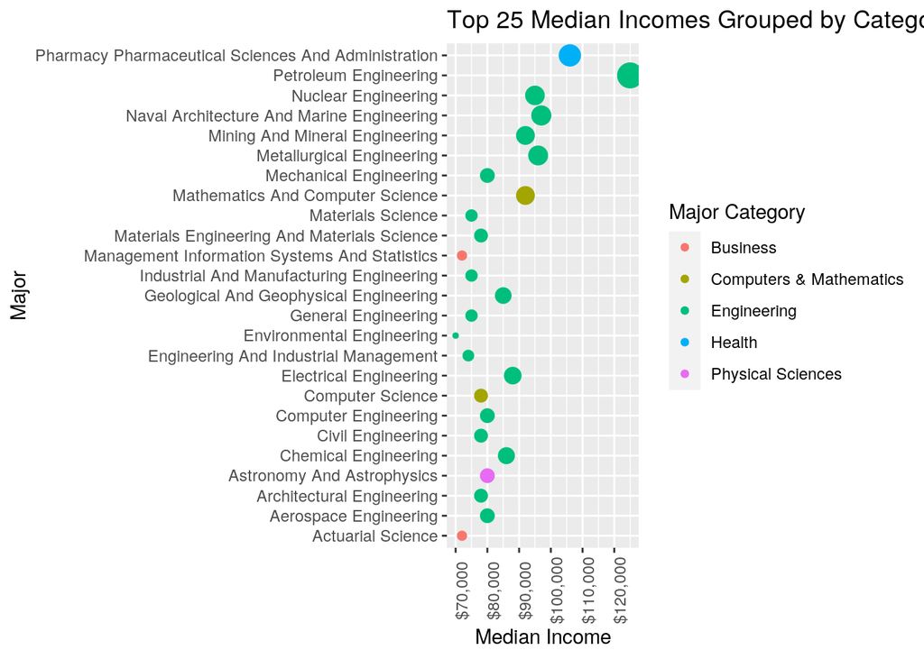

```r
set <- joined %>% arrange(desc(median)) %>% head(25)


ggplot(set, aes(major, median)) + geom_point(aes(color = major_category,
    size = median)) + theme(legend.position = "right") + scale_size(guide = "none") +
    coord_flip() + theme(axis.text.x = element_text(angle = 90)) +
    scale_y_continuous(labels = scales::dollar) + labs(color = "Major Category") +
    xlab("Major") + ylab("Median Income") + ggtitle("Top 25 Median Incomes Grouped by Category")
```

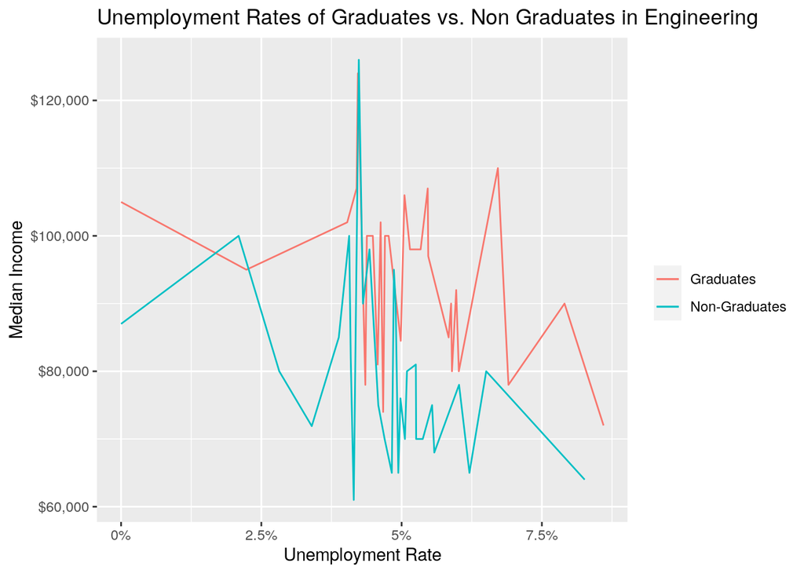

```r
joined %>% filter(major_category == "Engineering") %>% ggplot() +
    geom_line(aes(x = unemployment_rate, y = grad_median, color = "Graduates")) +
    geom_line(aes(x = nongrad_unemployment_rate, y = nongrad_median,
        color = "Non-Graduates")) + xlab("Unemployment Rate") +
    scale_x_continuous(breaks = seq(0, 0.1, 0.025), labels = c("0%",
        "2.5%", "5%", "7.5%", "10%")) + scale_y_continuous(labels = scales::dollar) +
    ylab("Median Income") + theme(legend.position = "right") +
    labs(color = " ") + ggtitle("Unemployment Rates of Graduates vs. Non Graduates in Engineering")
```

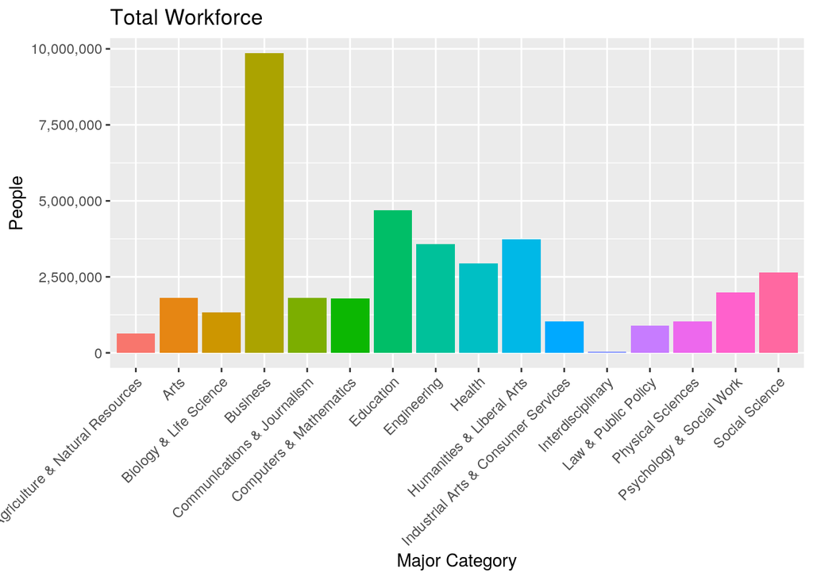

```r
joined %>% ggplot(aes(major_category)) + geom_bar(aes(y = total,
    fill = major_category), stat = "summary", fun = sum) + theme(axis.text.x = element_text(angle = 45,
    hjust = 1), legend.position = "none") + scale_y_continuous(breaks = seq(0,
    1000000000, 2500000), labels = scales::comma) + ggtitle("Total Workforce") +
    xlab("Major Category") + ylab("People")
```

[output not shown]